# Import and clean NDCP data

# Introduction

This script aims to produce descriptive statistics using the National Database of Childcare Prices 2008-2019 [(NDCP)](https://www.childandfamilydataarchive.org/cfda/archives/CFDA/studies/38303/versions/V1).

# Data

Note that each observation in the NDCP is at the `county-year` level. All prices are weekly, full-time median prices charged for a given Center-Based Care based on the results reported in the market rate survey report for the county. Details of each variable are found [here](https://www.dol.gov/sites/dolgov/files/WB/media/NationalDatabaseofChildcarePricesTechnicalGuideFinal.pdf) and are adjusted to 2018 levels.

# Process data

## Import data

```r
load(
  file.path(
    box_folder,
    "Data/raw-deintified",
    "National Database of Childcare Prices/2008-2018.rda"
    )
)
```

## Selecting variables of interest

This data set has a vast [array of variables](https://www.dol.gov/sites/dolgov/files/WB/media/NationalDatabaseofChildcarePricesTechnicalGuideFinal.pdf), so we subset the columns that we are interested in analyzing.

```r
ndcp_clean <-
  da38303.0001 %>%
  tibble() %>%
  clean_names() %>%
  zap_labels() %>%
  dplyr::select(
    state_name,
    state_abbreviation,
    county_name,
    county_fips_code,
    studyyear,
    pr_f,
    mhi,
    totalpop,
    me,
    fme,
    mme,
    contains("race"),
    hispanic,
    starts_with(c("h_","mc")),
    -ends_with("flag")
    )
```

## Rename `studyyear`

A slight renaming of this column is a matter of preference for later figures.

```r
ndcp_clean <-
  ndcp_clean %>%
  rename("year" = "studyyear")
```

## Compute yearly average price

We use `group_by` to group the data frame by `year` and compute the average median price.

```r
fig1 <-
  ndcp_clean %>%
  group_by(year) %>%
  summarise_at(
    c("mcsa",
      "mcinfant",
      "mctoddler",
      "mcpreschool"),
    ~ mean(.x, na.rm = TRUE)
  ) %>%
  ungroup()
```

## Reshape averages from wide to long

In order to plot each variable’s yearly average data points as separate into groups, it is easiest for me to reshape the data from the wide to long format.

```r
fig1 <-
  fig1 %>%
  pivot_longer(
    cols = c("mcsa",
             "mcinfant",
             "mctoddler",
             "mcpreschool"),
    names_to = "price_type",
    values_to = "price")
```

## Define `price_type`

```r
fig1 <-
  fig1 %>%
  mutate(
    price_type = case_when(
      price_type == "mcsa" ~ "School Age",
      price_type == "mcinfant" ~ "Infant",
      price_type == "mctoddler" ~ "Toddler",
      price_type == "mcpreschool" ~ "Preschool"),
    price_type =
      factor(
        price_type,
        levels =
        c("Infant",
          "Toddler",
          "Preschool",
          "School Age"))
    )
```

## Label data

Prior to plotting the data, we add variable labels to be inherited to the figure.

```r
fig1 <-
  fig1 %>%
  apply_labels(
    year = "Study Year",
    price = "Median Price ($)",
    price_type = "Type of Center-Based \n Child Care")
```

# Median child care price over time (Figure 1)

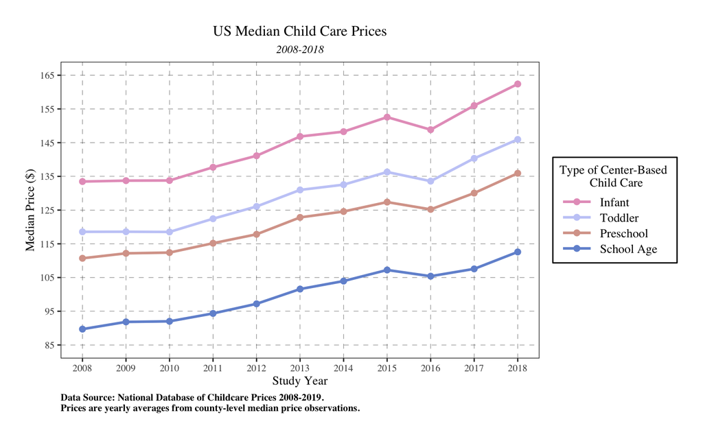

```r
fig1 <-
  ndcp_clean %>%
  group_by(year) %>%
  summarise_at(
    c("mcsa",
      "mcinfant",
      "mctoddler",
      "mcpreschool"),
    ~ mean(.x, na.rm = TRUE)
  ) %>%
  ungroup() %>%
  pivot_longer(
    cols = c("mcsa",
             "mcinfant",
             "mctoddler",
             "mcpreschool"),
    names_to = "price_type",
    values_to = "price") %>%
  mutate(
    price_type = case_when(
      price_type == "mcsa" ~ "School Age",
      price_type == "mcinfant" ~ "Infant",
      price_type == "mctoddler" ~ "Toddler",
      price_type == "mcpreschool" ~ "Preschool"),
    price_type =
      factor(
        price_type,
        levels =
        c("Infant",
          "Toddler",
          "Preschool",
          "School Age"))
    ) %>%
  apply_labels(
    year = "Study Year",
    price = "Median Price ($)",
    price_type = "Type of Center-Based \n Child Care") %>%
  ggplot() +
  geom_point(aes(x = year,
                 y = price,
                 group = price_type,
                 color = price_type),
             size = 2) +
  geom_line(aes(x = year,
                y = price,
                group = price_type,
                color = price_type),
            linewidth = 1) +
  theme_bw() +
  scale_x_continuous(
    breaks = 2008:2018,
    limits = c(2008, 2018)
  ) +
  easy_labs(title = "US Median Child Care Prices",
            subtitle = "2008-2018",
            caption = "Data Source: National Database of Childcare Prices 2008-2019. \nPrices are yearly averages from county-level median price observations.") +
  theme(text = element_text(family = "serif", size = 10),
        plot.title = element_text(size = 12, hjust = 0.5),
        plot.subtitle = element_text(size = 9 , hjust = 0.5, face = "italic"),
        plot.caption = element_text(face = "bold", hjust = 0),
        plot.margin = unit(c(0.75,0.75,0.75,0.75), "cm"),
        panel.grid.major.x =  element_line(color = "black",
                                           linewidth = 0.1,
                                           linetype = "dashed"),
        panel.grid.minor.x = element_blank(),
        panel.grid.major.y = element_line(color = "black",
                                          linewidth = 0.1,
                                          linetype="dashed"),
        panel.grid.minor.y =  element_blank(),
        legend.title = element_text(size = 10, hjust = 0.5),
        legend.key.width = unit(1,"cm"),
        legend.text = element_text(size = 10),
        legend.key.size = unit(0.45, 'cm'),
        legend.background = element_rect(
          colour = 'black',
          fill = NA,
          linetype = 'solid')
  ) +
  scale_y_continuous(limits = c(85, 165),
                     breaks = seq(85, 165, 10)) +
  scale_color_manual(values = wes_palette("GrandBudapest2"))

print(fig1)
```